# Time Series- Exploratory Data Analysis

Helen Yezerets

January 16, 2019

## Exploring raw time series

The most common first step when conducting time series analysis is to display your time series dataset in a visually intuitive format. The most useful way to view raw time series data in R is to use the print() command, which displays the Start, End, and Frequency of your data along with the observations.

Another useful command for viewing time series data in R is the length() function, which tells you the total number of observations in your data.

Some datasets are very long, and previewing a subset of data is more suitable than displaying the entire series. The head(*, n =*) and tail(*, n =*) functions, in which n is the number of items to display, focus on the first and last few elements of a given dataset respectively.

In this exercise, you’ll explore the famous River Nile annual streamflow data, Nile. This time series dataset includes some metadata information. When calling print(Nile), note that Start = 1871 indicates that 1871 is the year of the first annual observation, and End = 1970 indicates 1970 is the year of the last annual observation.

```
## Time Series:
## Start = 1871
## End = 1970
## Frequency = 1
##   [1] 1120 1160  963 1210 1160 1160  813 1230 1370 1140  995  935 1110  994
##  [15] 1020  960 1180  799  958 1140 1100 1210 1150 1250 1260 1220 1030 1100
##  [29]  774  840  874  694  940  833  701  916  692 1020 1050  969  831  726
##  [43]  456  824  702 1120 1100  832  764  821  768  845  864  862  698  845
##  [57]  744  796 1040  759  781  865  845  944  984  897  822 1010  771  676
##  [71]  649  846  812  742  801 1040  860  874  848  890  744  749  838 1050
##  [85]  918  986  797  923  975  815 1020  906  901 1170  912  746  919  718
##  [99]  714  740
```

```
## [1] 100
```

```
##  [1] 1120 1160  963 1210 1160 1160  813 1230 1370 1140
```

```
##  [1]  975  815 1020  906  901 1170  912  746  919  718  714  740
```

## Basic time series plots

While simple commands such as print(), length(), head(), and tail() provide crucial information about your time series data, another very useful way to explore any data is to generate a plot.

In this exercise, you will plot the River Nile annual streamflow data using the plot() function. For time series data objects such as Nile, a Time index for the horizontal axis is typically included. From the previous exercise, you know that this data spans from 1871 to 1970, and horizontal tick marks are labeled as such. The default label of “Time” is not very informative. Since these data are annual measurements, you should use the label “Year”. While you’re at it, you should change the vertical axis label to “River Volume (1e9 m^{3})”.

Additionally, it helps to have an informative title, which can be set using the argument **main**. For your purposes, a useful title for this figure would be “Annual River Nile Volume at Aswan, 1871-1970”.

Finally, the default plotting type for time series objects is **l** for line. Connecting consecutive observations can help make a time series plot more interpretable. Sometimes it is also useful to include both the observations points as well as the lines, and we instead use **b** for both.

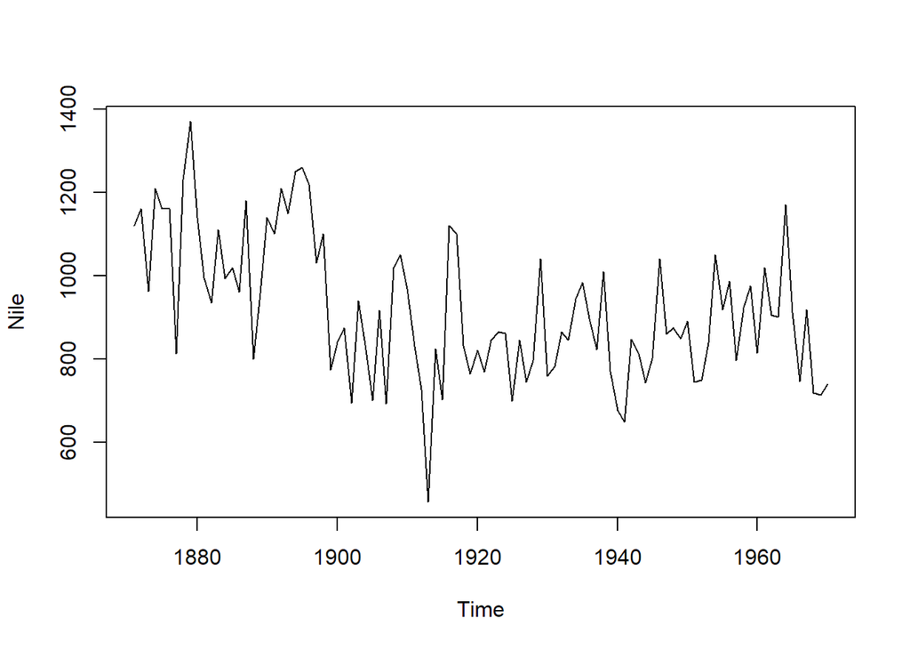

```r
# Plot the Nile data
plot(Nile)
```

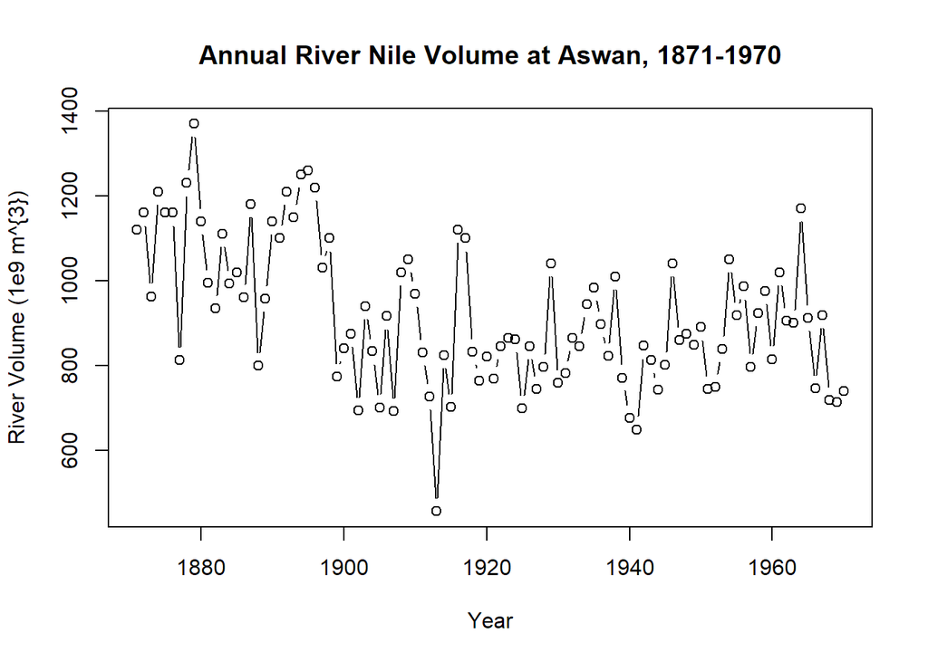

```r
# Plot the Nile data with xlab, ylab, main, and type arguments
plot(Nile, xlab = "Year", ylab = "River Volume (1e9 m^{3})",
main = "Annual River Nile Volume at Aswan, 1871-1970", type ="b")
```

## What does the time index tell us?

```r
# Plot the continuous_series using continuous time indexing
par(mfrow=c(2,1))
#plot(continuous_time_index,continuous_series, type = "b")

# Make a discrete time index using 1:20
discrete_time_index <-c(1:20)

# Now plot the continuous_series using discrete time indexing
#plot(discrete_time_index,continuous_series, type = "b")
```

## Identifying the sampling frequency

In addition to viewing your data and plotting over time, there are several additional operations that can be performed on time series datasets.

- start() and end() functions return the time index of the first and last observations, respectively.
- time() function calculates a vector of time indices, with one element for each time index on which the series was observed.
- deltat() function returns the fixed time interval between observations
- frequency() function returns the number of observations per unit time.
- cycle() function returns the position in the cycle of each observation.

In this exercise, you’ll practice applying these functions to the AirPassengers dataset, which reports the monthly total international airline passengers (in thousands) from 1949 to 1960.

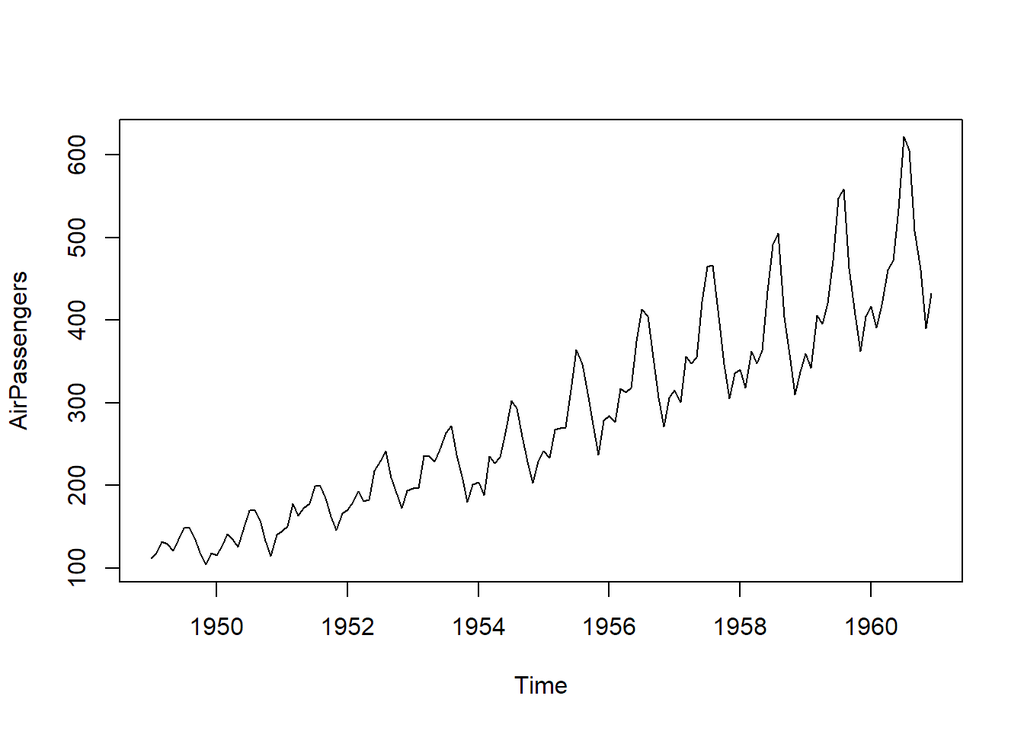

```r
# Plot AirPassengers
plot(AirPassengers)
```

```r
# View the start and end dates of AirPassengers
start(AirPassengers)
```

```
## [1] 1949    1
```

```r
end(AirPassengers)
```

```
## [1] 1960   12
```

```r
# Use time(), deltat(), frequency(), and cycle() with AirPassengers
```

# - time() function calculates a vector of time indices, with one element for each time index on which the series was observed.

```r
 time(AirPassengers)
```

```
##           Jan      Feb      Mar      Apr      May      Jun      Jul
## 1949 1949.000 1949.083 1949.167 1949.250 1949.333 1949.417 1949.500
## 1950 1950.000 1950.083 1950.167 1950.250 1950.333 1950.417 1950.500
## 1951 1951.000 1951.083 1951.167 1951.250 1951.333 1951.417 1951.500
## 1952 1952.000 1952.083 1952.167 1952.250 1952.333 1952.417 1952.500
## 1953 1953.000 1953.083 1953.167 1953.250 1953.333 1953.417 1953.500
## 1954 1954.000 1954.083 1954.167 1954.250 1954.333 1954.417 1954.500
## 1955 1955.000 1955.083 1955.167 1955.250 1955.333 1955.417 1955.500
## 1956 1956.000 1956.083 1956.167 1956.250 1956.333 1956.417 1956.500
## 1957 1957.000 1957.083 1957.167 1957.250 1957.333 1957.417 1957.500
## 1958 1958.000 1958.083 1958.167 1958.250 1958.333 1958.417 1958.500
## 1959 1959.000 1959.083 1959.167 1959.250 1959.333 1959.417 1959.500
## 1960 1960.000 1960.083 1960.167 1960.250 1960.333 1960.417 1960.500
##           Aug      Sep      Oct      Nov      Dec
## 1949 1949.583 1949.667 1949.750 1949.833 1949.917
## 1950 1950.583 1950.667 1950.750 1950.833 1950.917
## 1951 1951.583 1951.667 1951.750 1951.833 1951.917
## 1952 1952.583 1952.667 1952.750 1952.833 1952.917
## 1953 1953.583 1953.667 1953.750 1953.833 1953.917
## 1954 1954.583 1954.667 1954.750 1954.833 1954.917
## 1955 1955.583 1955.667 1955.750 1955.833 1955.917
## 1956 1956.583 1956.667 1956.750 1956.833 1956.917
## 1957 1957.583 1957.667 1957.750 1957.833 1957.917
## 1958 1958.583 1958.667 1958.750 1958.833 1958.917
## 1959 1959.583 1959.667 1959.750 1959.833 1959.917
## 1960 1960.583 1960.667 1960.750 1960.833 1960.917
```

# - deltat() function returns the fixed time interval between observations

```r
deltat(AirPassengers)
```

```
## [1] 0.08333333
```

### Frequency

```r
# - frequency() function returns the number of observations per unit time.
 frequency(AirPassengers)
```

```
## [1] 12
```

### Cycle

```r
# - cycle() function returns the position in the cycle of each observation.
 cycle(AirPassengers)
```

```
##      Jan Feb Mar Apr May Jun Jul Aug Sep Oct Nov Dec
## 1949   1   2   3   4   5   6   7   8   9  10  11  12
## 1950   1   2   3   4   5   6   7   8   9  10  11  12
## 1951   1   2   3   4   5   6   7   8   9  10  11  12
## 1952   1   2   3   4   5   6   7   8   9  10  11  12
## 1953   1   2   3   4   5   6   7   8   9  10  11  12
## 1954   1   2   3   4   5   6   7   8   9  10  11  12
## 1955   1   2   3   4   5   6   7   8   9  10  11  12
## 1956   1   2   3   4   5   6   7   8   9  10  11  12
## 1957   1   2   3   4   5   6   7   8   9  10  11  12
## 1958   1   2   3   4   5   6   7   8   9  10  11  12
## 1959   1   2   3   4   5   6   7   8   9  10  11  12
## 1960   1   2   3   4   5   6   7   8   9  10  11  12
```

## Missing values

Sometimes there are missing values in time series data, denoted NA in R, and it is useful to know their locations. It is also important to know how missing values are handled by various R functions. Sometimes we may want to ignore any missingness, but other times we may wish to **impute or estimate the missing values**.

Let’s again consider the monthly AirPassengers dataset, but now the data for the year 1956 are missing. In this exercise, you’ll explore the implications of this missing data and impute some new data to solve the problem.

- **mean()** function calculates the sample mean, but it fails in the presence of any NA values. Use **mean(___, na.rm = TRUE)** to calculate the mean with all missing values removed. It is common to replace missing values with the mean of the observed values. Does this simple data imputation scheme appear adequate when applied the the AirPassengers dataset?

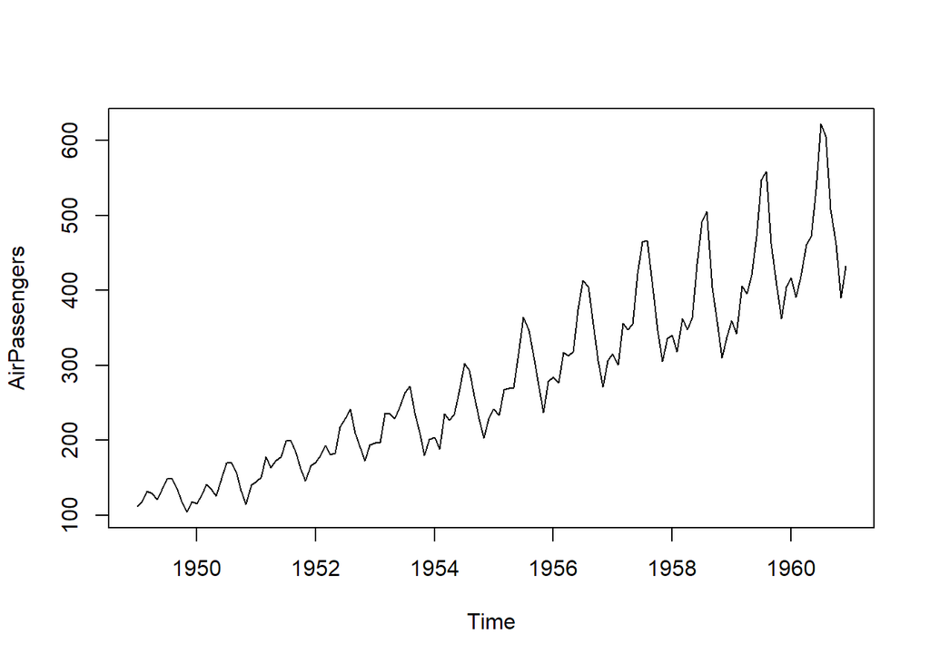

```r
# Plot the AirPassengers data
plot(AirPassengers)
```

```r
# Compute the mean of AirPassengers
mean(AirPassengers, na.rm=TRUE)
```

```
## [1] 280.2986
```

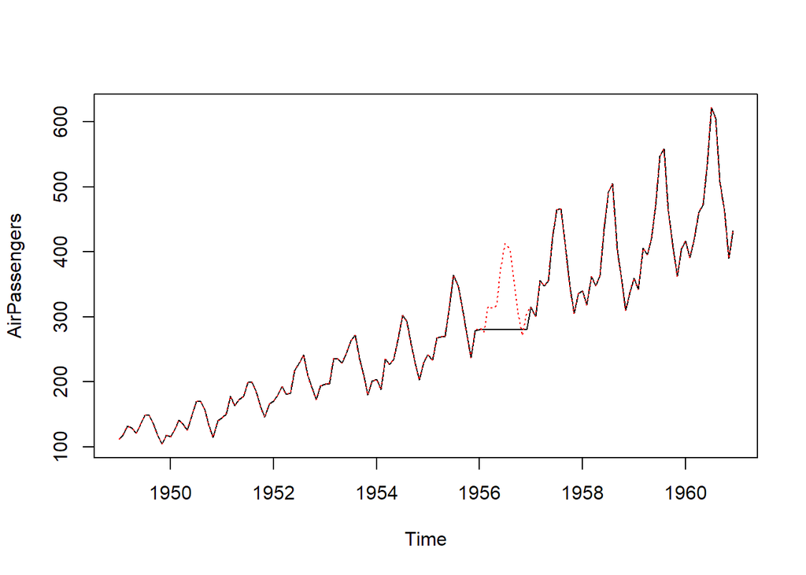

```r
# Impute mean values to NA in AirPassengers
AirPassengers[85:96] <- mean(AirPassengers, na.rm = TRUE)
# Generate another plot of AirPassengers
plot(AirPassengers)
# Add the complete AirPassengers data to your plot
rm(AirPassengers)
points(AirPassengers, type = "l", col = 2, lty = 3)
```

## Creating a time series object with ts()

The function **ts()** can be applied to create time series objects. A time series object is a vector (univariate) or matrix (multivariate) with additional attributes, including time indices for each observation, the sampling frequency and time increment between observations, and the cycle length for periodic data. Such objects are of the ts class, and represent data that has been observed at (approximately) equally spaced time points. Now you will create time series objects yourself.

The advantage of creating and working with time series objects of the **ts** class is that many methods are available for utilizing time series attributes, such as time index information. For example, as you’ve seen in earlier exercises, calling **plot()** on a ts object will automatically generate a plot over time.

In this exercise, you’ll familiarize yourself with the **ts** class by encoding some time series data (saved as data_vector) into ts and exploring the result. Your time series **data_vector** starts in the year 2004 and has 4 observations per year (i.e. it is quarterly data).

```r
# Use print() and plot() to view data_vector
data_vector<-c(10,6,11,8,10,3,6.9)

print(data_vector)
```

```
## [1] 10.0  6.0 11.0  8.0 10.0  3.0  6.9
```

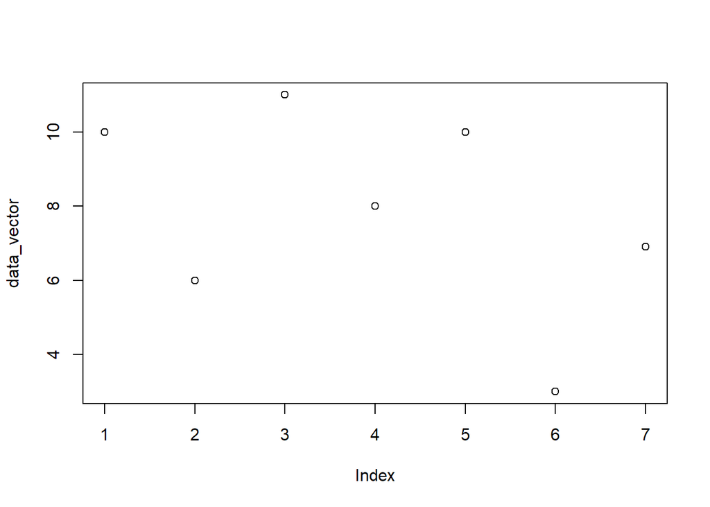

```r
plot(data_vector)
```

```r
# Convert data_vector to a ts object with start = 2004 and frequency = 4
time_series <- ts(data_vector, start=2004, frequency = 4)

# Use print() and plot() to view time_series
print(time_series)
```

```
##      Qtr1 Qtr2 Qtr3 Qtr4
## 2004 10.0  6.0 11.0  8.0
## 2005 10.0  3.0  6.9
```

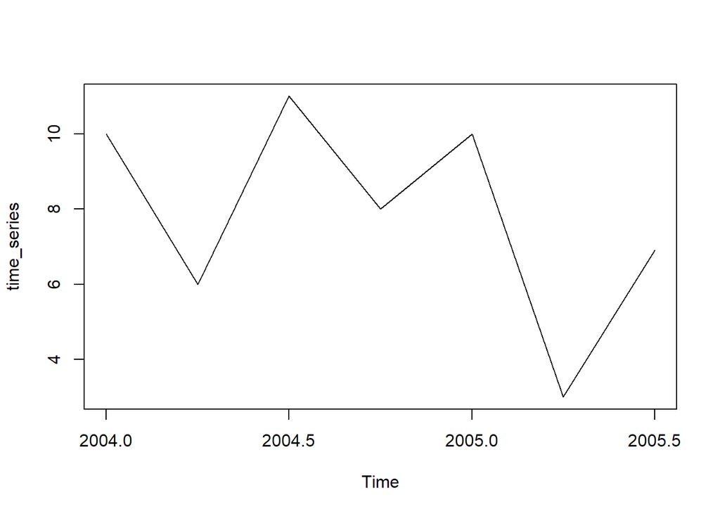

```r
plot(time_series)
```

## Testing whether an object is a time series

When you use datasets from others, such as those included in an R package, you can check whether they are ts objects using the *is.ts()* command. The result of the test is either TRUE when the data is of the ts class, or FALSE if it is not.

In this exercise, you’ll explore the class of the datasets you’ve been using throughout this chapter.

```r
# Check whether data_vector and time_series are ts objects

is.ts(data_vector)
```

```
## [1] FALSE
```

```r
is.ts(time_series)
```

```
## [1] TRUE
```

```r
# Check whether Nile is a ts object

is.ts(Nile)
```

```
## [1] TRUE
```

```r
# Check whether AirPassengers is a ts object
is.ts(AirPassengers)
```

```
## [1] TRUE
```

## Plotting a time series object

It is often very useful to plot data we are analyzing, as is the case when conducting time series analysis. If the dataset under study is of the ts class, then the **plot()** function has methods that automatically incorporate time index information into a figure.

Let’s consider the eu_stocks dataset (available in R by default as *EuStockMarkets*). This dataset contains daily closing prices of major European stock indices from 1991-1998, specifically, from Germany (DAX), Switzerland (SMI), France (CAC), and the UK (FTSE). The data were observed when the markets were open, so there are no observations on weekends and holidays. We will proceed with the approximation that this dataset has evenly spaced observations and is a four dimensional time series.

To conclude this chapter, this exercise asks you to apply several of the functions you’ve already learned to this new dataset.

```r
# Check whether eu_stocks is a ts object
is.ts(EuStockMarkets)
```

```
## [1] TRUE
```

```r
# View the start, end, and frequency of eu_stocks
eu_stocks<-EuStockMarkets
start(eu_stocks)
```

```
## [1] 1991  130
```

```r
end(eu_stocks)
```

```
## [1] 1998  169
```

```r
frequency(eu_stocks)
```

```
## [1] 260
```

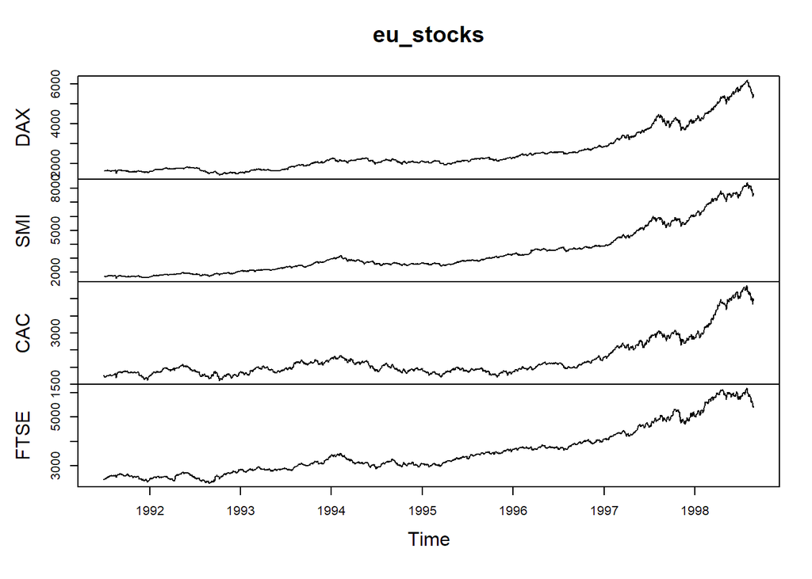

```r
# Generate a simple plot of eu_stocks
plot(eu_stocks)
```

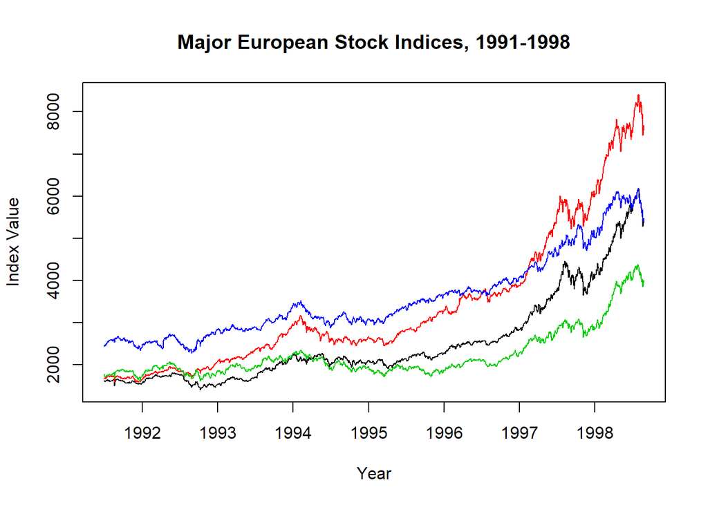

```r
# Use ts.plot with eu_stocks
ts.plot(eu_stocks, col = 1:4, xlab = "Year", ylab = "Index Value", main = "Major European Stock Indices, 1991-1998")
```

## Introduction to time series data. Chapter 1 in Cowpertwait & Meltcalfe (2009)

### sections 1.1-1.4

### Recursive functions: Factorial

```r
Fact <- function(n) if (n == 1) 1 else n * Fact(n - 1)
Fact(5)
```

```
## [1] 120
```

```r
#data(AirPassengers)
AP <- AirPassengers
AP
```

```
##      Jan Feb Mar Apr May Jun Jul Aug Sep Oct Nov Dec
## 1949 112 118 132 129 121 135 148 148 136 119 104 118
## 1950 115 126 141 135 125 149 170 170 158 133 114 140
## 1951 145 150 178 163 172 178 199 199 184 162 146 166
## 1952 171 180 193 181 183 218 230 242 209 191 172 194
## 1953 196 196 236 235 229 243 264 272 237 211 180 201
## 1954 204 188 235 227 234 264 302 293 259 229 203 229
## 1955 242 233 267 269 270 315 364 347 312 274 237 278
## 1956 284 277 317 313 318 374 413 405 355 306 271 306
## 1957 315 301 356 348 355 422 465 467 404 347 305 336
## 1958 340 318 362 348 363 435 491 505 404 359 310 337
## 1959 360 342 406 396 420 472 548 559 463 407 362 405
## 1960 417 391 419 461 472 535 622 606 508 461 390 432
```

```r
class(AP)
```

```
## [1] "ts"
```

```r
start(AP); end(AP); frequency(AP)
```

```
## [1] 1949    1
```

```
## [1] 1960   12
```

```
## [1] 12
```

```r
summary(AP)
```

```
##    Min. 1st Qu.  Median    Mean 3rd Qu.    Max.
##   104.0   180.0   265.5   280.3   360.5   622.0
```

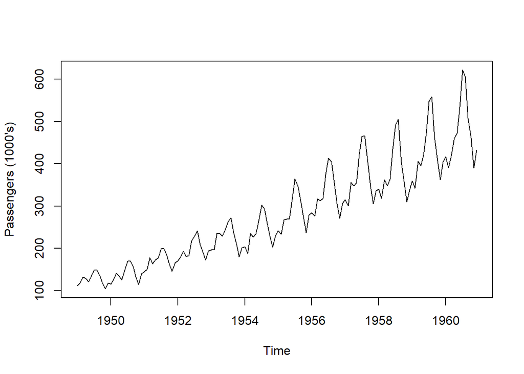

```r
plot(AP, ylab = "Passengers (1000's)")
```

## Seasonal Effect

To get a clearer view of the trend, the seasonal effect can be removed by **aggregating the data to the annual level**, which can be achieved in R using the *aggregate()* function. A **summary** of the values for each season can be viewed using a boxplot, with the **cycle** function being used to *extract the seasons for each item of data*.

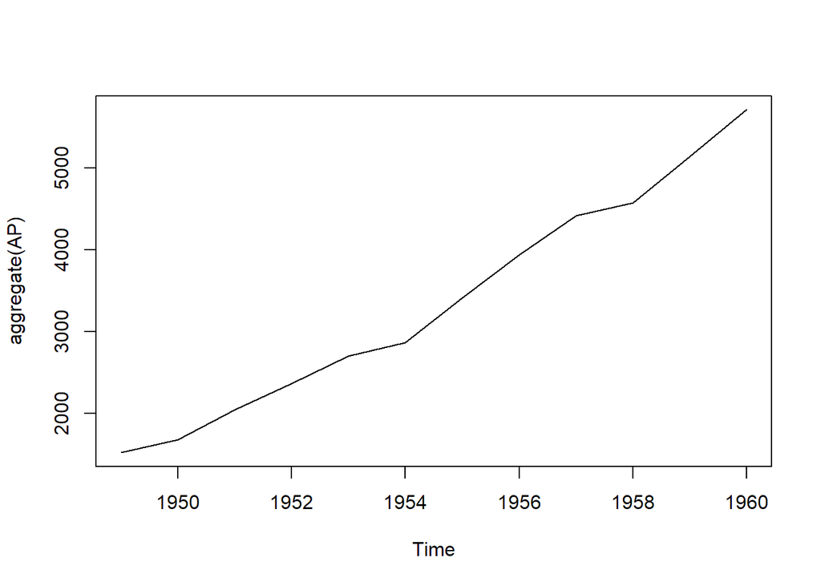

```r
layout(1:1)
plot(aggregate(AP))
```

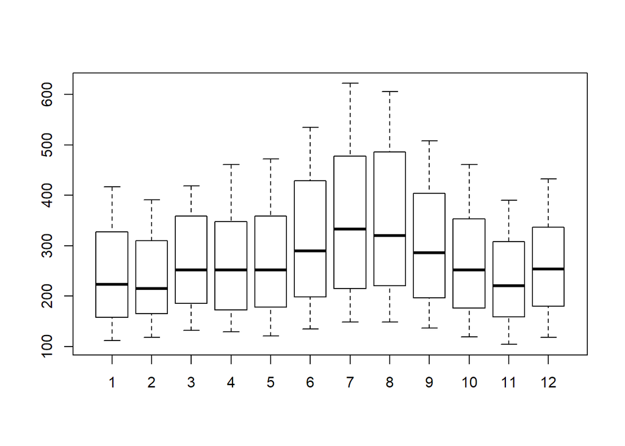

```r
boxplot(AP ~ cycle(AP))
```

```r
Maine.month <- read.delim("../Data/Maine.dat", header=TRUE)

#Maine.month <- read.table(www, header = TRUE)
attach(Maine.month)
class(Maine.month)
```

```
## [1] "data.frame"
```

```r
Maine.month.ts <- ts(unemploy, start = c(1996, 1), frequency = 12)
```

This uses all the data. You can select a smaller number by specifying an earlier end date using the parameter end. If we wish to analyse trends in the unemployment rate, annual data will suffice. The average (mean) over the twelve months of each year is another example of aggregated data, but this time we divide by 12 to give a mean annual rate.

```r
Maine.annual.ts <- aggregate(Maine.month.ts)/12
```

We now plot both time series. There is clear monthly variation. From Figure 1.3(a) it seems that the February figure is typically about 20% more than the annual average, whereas the August figure tends to be roughly 20% less.

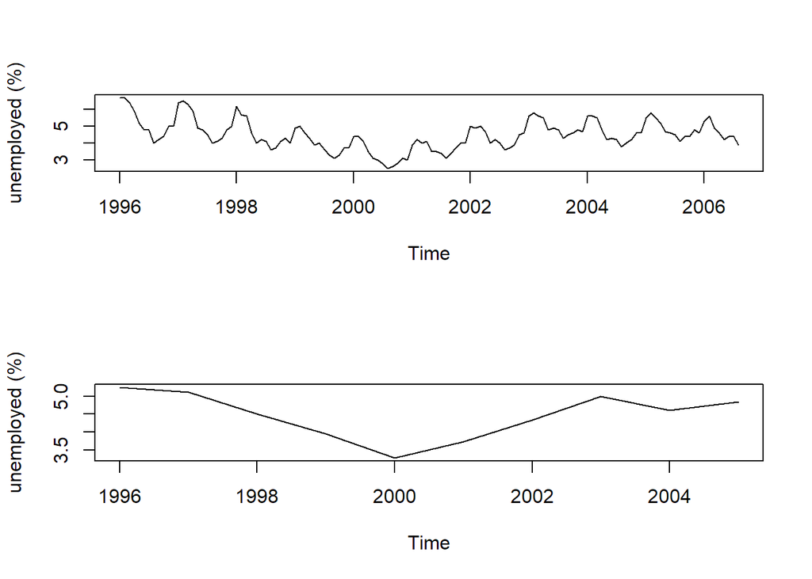

```r
layout(1:2)
plot(Maine.month.ts, ylab = "unemployed (%)")
plot(Maine.annual.ts, ylab = "unemployed (%)")
```

```r
Maine.Feb <- window(Maine.month.ts, start = c(1996,2), freq = TRUE)
Maine.Aug <- window(Maine.month.ts, start = c(1996,8), freq = TRUE)
Feb.ratio <- mean(Maine.Feb) / mean(Maine.month.ts)
Aug.ratio <- mean(Maine.Aug) / mean(Maine.month.ts)


Maine.Feb
```

```
## Time Series:
## Start = 1996.083
## End = 2006.083
## Frequency = 1
##  [1] 6.7 6.5 5.7 5.0 4.4 4.2 4.9 5.8 5.6 5.8 5.6
```

```r
Maine.Aug
```

```
## Time Series:
## Start = 1996.583
## End = 2006.583
## Frequency = 1
##  [1] 4.0 4.0 3.6 3.3 2.5 3.1 3.6 4.3 3.8 4.1 3.9
```

```r
Feb.ratio
```

```
## [1] 1.222529
```

```r
Aug.ratio
```

```
## [1] 0.8163732
```

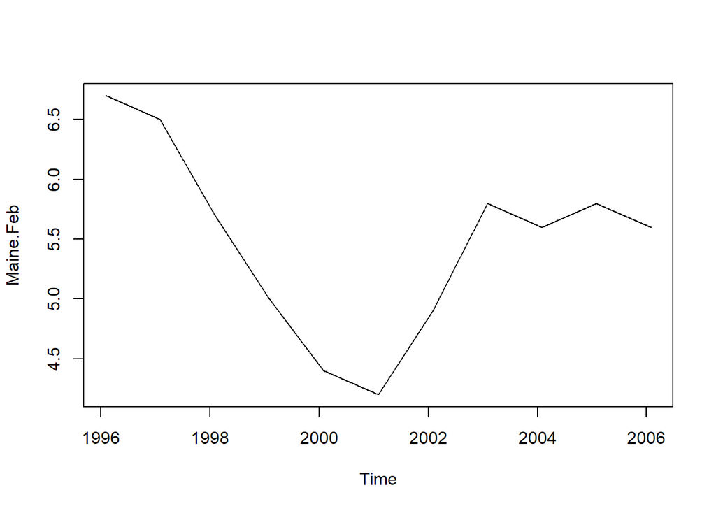

```r
layout(1:1)
plot(Maine.Feb)
```

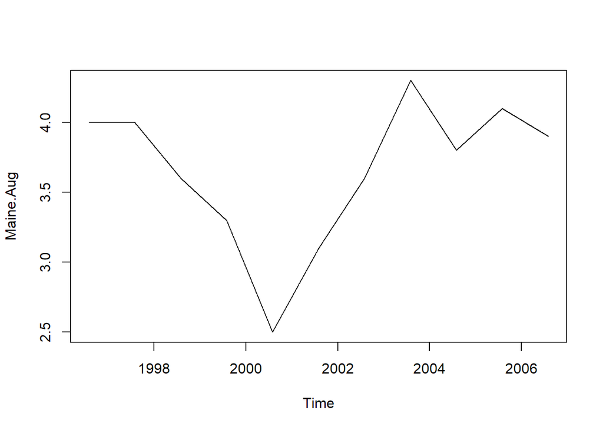

```r
plot(Maine.Aug)
```

```r
x <- c(1,2,3)

y <- matrix(c(3,1,2,2,1,3,3,2,1), ncol = 3, byrow = TRUE)
```

```r
y
```

```
##      [,1] [,2] [,3]
## [1,]    3    1    2
## [2,]    2    1    3
## [3,]    3    2    1
```

```r
t(y)
```

```
##      [,1] [,2] [,3]
## [1,]    3    2    3
## [2,]    1    1    2
## [3,]    2    3    1
```

```r
x%*%t(y)
```

```
##      [,1] [,2] [,3]
## [1,]   11   13   10
```

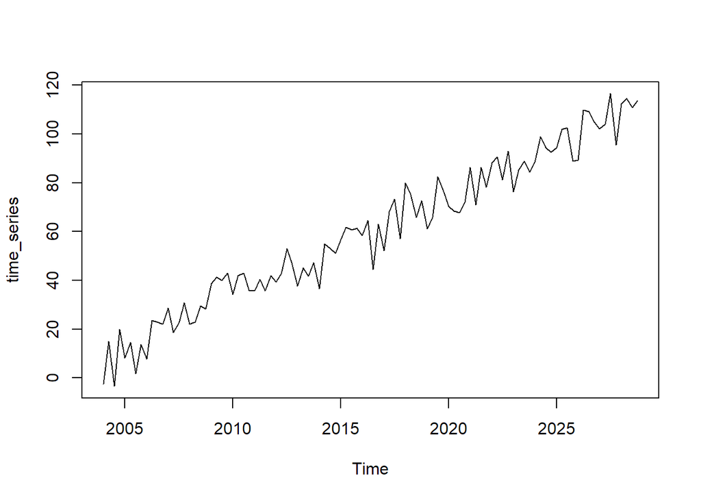

```r
t <- seq(from = 1, to = 100, by = 1) + 10 + rnorm(100, sd = 7)
time_series<- ts(t, start=2004, frequency = 4)
plot(time_series)
```

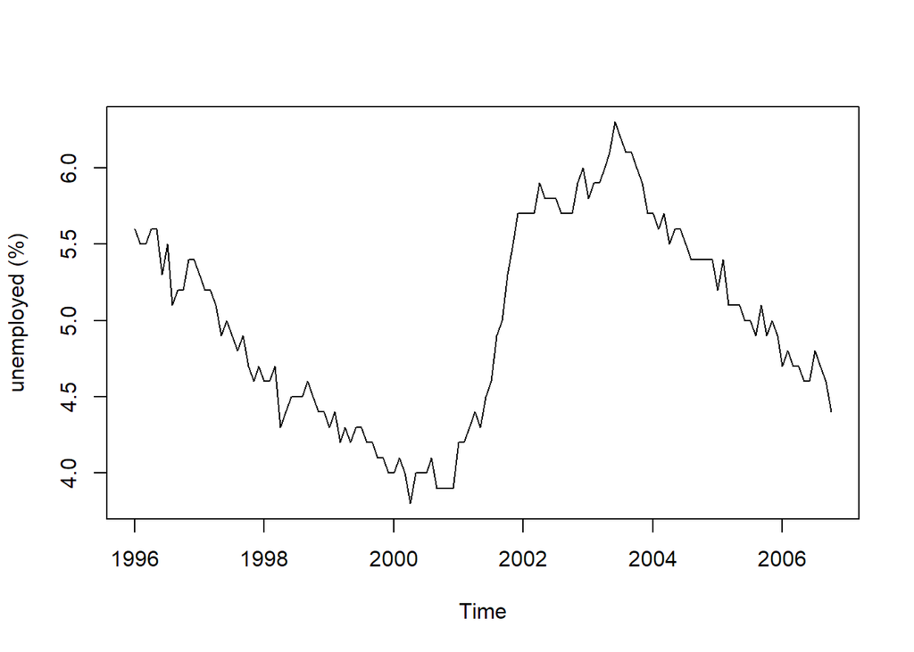

```r
#www <- "http://www.massey.ac.nz/~pscowper/ts/USunemp.dat"
US.month <- read.delim("../Data/USunemp.dat", header=TRUE)

attach(US.month)
US.month.ts <- ts(US.month, start=c(1996,1), end=c(2006,10), frequency = 12)
plot(US.month.ts, ylab = "unemployed (%)")
```

The monthly supply of electricity (millions of kWh), beer (Ml), and chocolate-based production (tonnes) in Australia over the period January 1958 to December 1990 are available from the Australian Bureau of Statistics (ABS).

```r
#www <- "http://www.massey.ac.nz/~pscowper/ts/cbe.dat"
CBE <- read.delim("../Data/cbe.dat", header = T)
CBE[1:4, ]
```

```
##   choc beer elec
## 1 1451 96.3 1497
## 2 2037 84.4 1463
## 3 2477 91.2 1648
## 4 2785 81.9 1595
```

```r
class(CBE)
```

```
## [1] "data.frame"
```

create time series objects for the electricity, beer, and chocolate data. If you omit end, R uses the full length of the vector, and if you omit the month in start, R assumes 1. You can use plot with cbind to plot several series on one figure (Fig. 1.5).

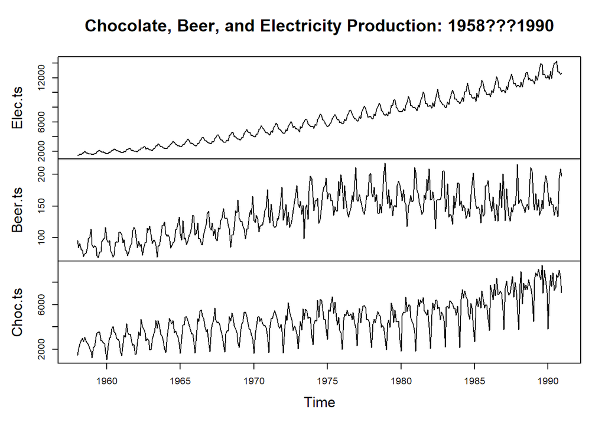

```r
Elec.ts <- ts(CBE[, 3], start = 1958, frequency =  12)
Beer.ts <- ts(CBE[, 2], start = 1958, frequency =  12)
Choc.ts <- ts(CBE[, 1], start = 1958, frequency =  12)
plot(cbind(Elec.ts, Beer.ts, Choc.ts), main="Chocolate, Beer, and Electricity Production: 1958???1990")
```

The intersection between the air passenger data and the electricity data is obtained as follows

```r
AP.elec <- ts.intersect(AP, Elec.ts)
start(AP.elec)
```

```
## [1] 1958    1
```

```r
#[1] 1958 1
```

```r
end(AP.elec)
```

```
## [1] 1960   12
```

```r
#[1] 1960 12
```

```r
AP.elec[1:3, ]
```

```
##       AP Elec.ts
## [1,] 340    1497
## [2,] 318    1463
## [3,] 362    1648
```

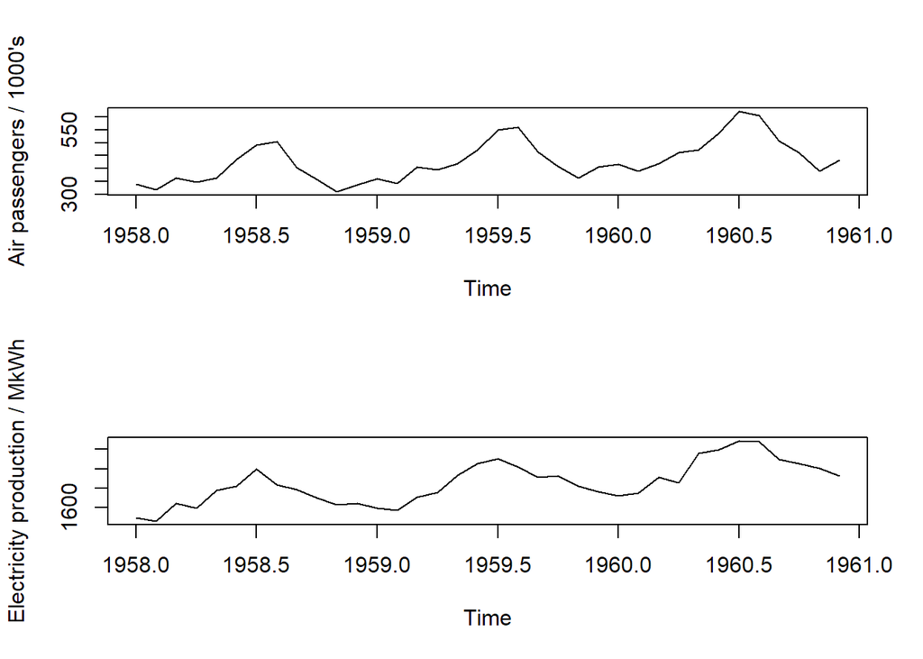

```r
AP <- AP.elec[,1]; Elec <- AP.elec[,2]
layout(1:2)
plot(AP, main = "", ylab = "Air passengers / 1000's")
plot(Elec, main = "", ylab = "Electricity production / MkWh")
```

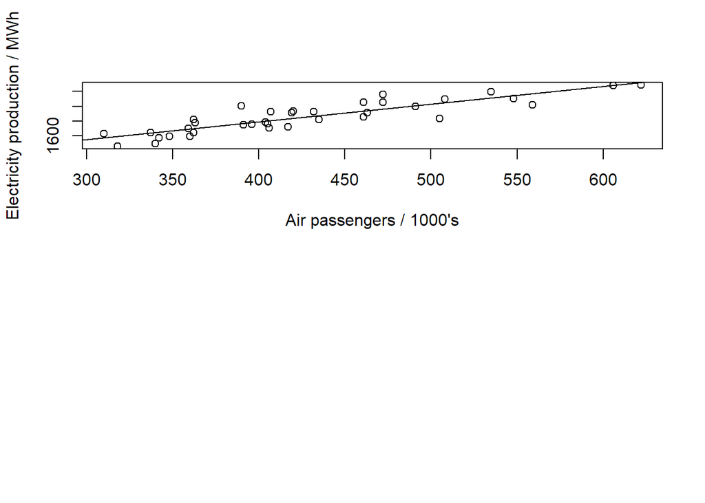

```r
plot(as.vector(AP), as.vector(Elec),xlab = "Air passengers / 1000's",ylab = "Electricity production / MWh")
abline(reg = lm(Elec ~ AP))
```

##High correlation

```r
cor(AP, Elec)
```

```
## [1] 0.8841668
```

In the plot function above, as.vector is needed to convert the ts objects to ordinary vectors suitable for a scatter plot.

```r
#www <- "http://www.massey.ac.nz/~pscowper/ts/pounds_nz.dat"
Z <- read.delim("../Data/pounds_nz.dat", header = T)
Z[1:4, ]
```

```
## [1] 2.9243 2.9422 3.1719 3.2542
```

```r
#[1] 2.92 2.94 3.17 3.25
```

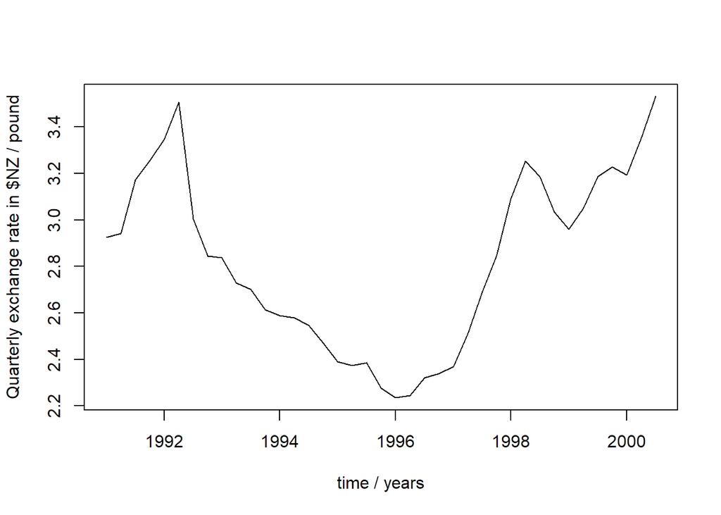

```r
Z.ts <- ts(Z, start = 1991, frequency = 4)
plot(Z.ts, xlab = "time / years",
ylab = "Quarterly exchange rate in $NZ / pound")
```

Two local trends are emphasised when the series is partitioned into two subseries based on the periods 1992-1996 and 1996-1998. The window function can be used to extract the subseries:

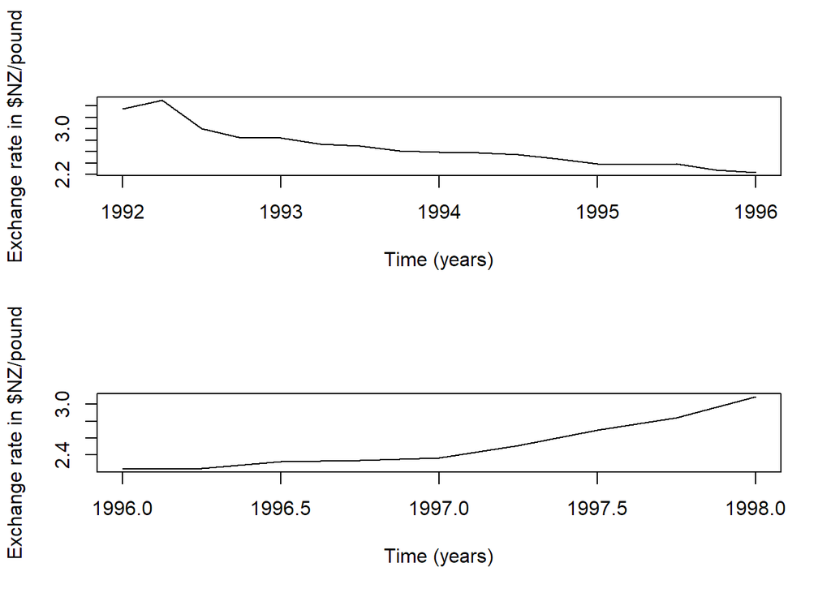

```r
Z.92.96 <- window(Z.ts, start = c(1992, 1), end = c(1996, 1))
Z.96.98 <- window(Z.ts, start = c(1996, 1), end = c(1998, 1))
layout (1:2)
plot(Z.92.96, ylab = "Exchange rate in $NZ/pound", xlab = "Time (years)" )
plot(Z.96.98, ylab = "Exchange rate in $NZ/pound", xlab = "Time (years)" )
```

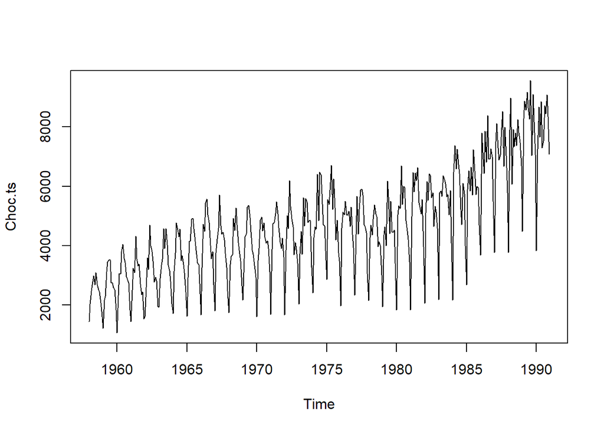

```r
#www <- "global.dat"
#Global <- scan(www)
#Global.ts <- ts(Global, start = c(1856, 1), end = c(2005, 12),frequency =  12)
Choc.annual <- aggregate(Choc.ts, FUN = mean)
plot(Choc.ts)
```

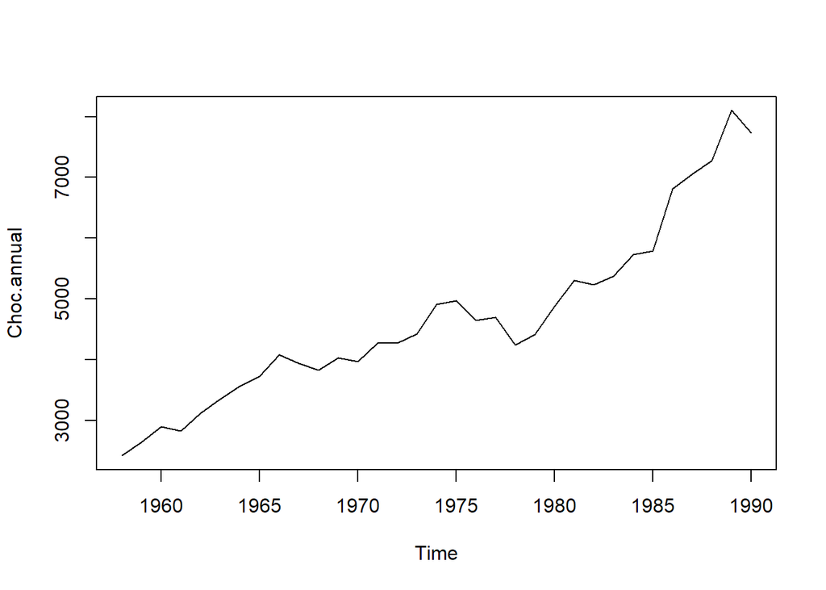

```r
plot(Choc.annual)
```

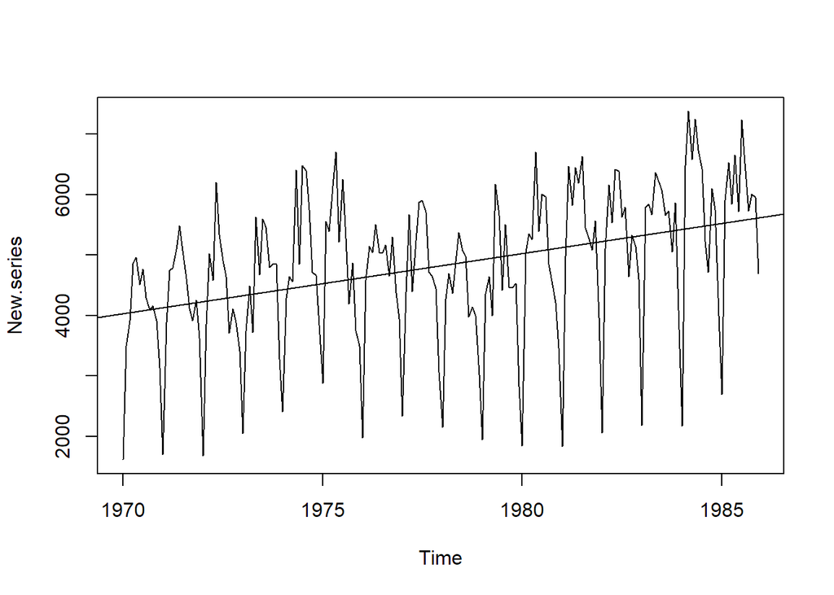

```r
New.series <- window(Choc.ts, start=c(1970, 1), end=c(1985, 12))
New.time <- time(New.series)
plot(New.series); abline(reg=lm(New.series ~ New.time))
```